# Healing or Harming? The Silent Crisis in Healthcare Sanitation

A UNICEF Data Report on Sanitation in Health Facilities Worldwide

Author

Ashish Vattam

Published

January 1, 2025

```python
indicator2 = pl.read_csv("unicef_indicator_2.csv")
metadata   = pl.read_csv("unicef_metadata.csv")

print(f"Indicator 2 shape  : {indicator2.shape}")
print(f"Metadata shape     : {metadata.shape}")
```

```
Indicator 2 shape  : (1822, 14)
Metadata shape     : (13715, 15)
```

```python
print("=== Indicator 2 – obs_value summary ===")
print(indicator2.select("obs_value").describe())
print("\n=== Null counts ===")
print(indicator2.null_count())
n_countries = indicator2.select("country").n_unique()
year_min    = indicator2.select("time_period").min().item()
year_max    = indicator2.select("time_period").max().item()
print(f"\nCountries: {n_countries} | Years: {year_min}–{year_max}")
```

```
=== Indicator 2 – obs_value summary ===
shape: (9, 2)
┌────────────┬───────────┐
│ statistic  ┆ obs_value │
│ ---        ┆ ---       │
│ str        ┆ f64       │
╞════════════╪═══════════╡
│ count      ┆ 1822.0    │
│ null_count ┆ 0.0       │
│ mean       ┆ 8.497795  │
│ std        ┆ 13.506428 │
│ min        ┆ 0.0       │
│ 25%        ┆ 0.0       │
│ 50%        ┆ 2.741285  │
│ 75%        ┆ 10.9      │
│ max        ┆ 71.989305 │
└────────────┴───────────┘

=== Null counts ===
shape: (1, 14)
┌─────────┬────────────┬───────────┬───────────┬───┬───────────┬───────────┬───────────┬───────────┐
│ country ┆ alpha_2_co ┆ alpha_3_c ┆ numeric_c ┆ … ┆ observati ┆ observati ┆ time_peri ┆ current_a │
│ ---     ┆ de         ┆ ode       ┆ ode       ┆   ┆ on_status ┆ on_confid ┆ od_activi ┆ ge        │
│ u32     ┆ ---        ┆ ---       ┆ ---       ┆   ┆ ---       ┆ entaility ┆ ty_relate ┆ ---       │
│         ┆ u32        ┆ u32       ┆ u32       ┆   ┆ u32       ┆ ---       ┆ d_t…      ┆ u32       │
│         ┆            ┆           ┆           ┆   ┆           ┆ u32       ┆ ---       ┆           │
│         ┆            ┆           ┆           ┆   ┆           ┆           ┆ u32       ┆           │
╞═════════╪════════════╪═══════════╪═══════════╪═══╪═══════════╪═══════════╪═══════════╪═══════════╡
│ 0       ┆ 9          ┆ 0         ┆ 0         ┆ … ┆ 1822      ┆ 1822      ┆ 1822      ┆ 0         │
└─────────┴────────────┴───────────┴───────────┴───┴───────────┴───────────┴───────────┴───────────┘

Countries: 119 | Years: 2000–2023
```

```python
ind2_total = (
    indicator2
    .filter(pl.col("sex") == "Total")
    .select(["country", "alpha_3_code", "time_period", "obs_value"])
)
country_avg = (
    ind2_total
    .group_by("country", "alpha_3_code")
    .agg(pl.col("obs_value").mean().alias("avg_no_sanitation"))
    .sort("avg_no_sanitation", descending=True)
)
meta_clean = (
    metadata
    .select(["country","alpha_3_code","year",
             "Life expectancy at birth, total (years)",
             "GDP per capita (constant 2015 US$)","Population, total"])
    .rename({"Life expectancy at birth, total (years)":"life_exp",
             "GDP per capita (constant 2015 US$)":"gdp_pc",
             "Population, total":"pop"})
    .filter(pl.col("year") >= 2015)
)
scatter_df = (
    ind2_total
    .filter(pl.col("time_period") >= 2015)
    .join(meta_clean, left_on=["alpha_3_code","time_period"], right_on=["alpha_3_code","year"], how="inner")
    .drop("country_right")
    .filter(pl.col("life_exp").is_not_null())
    .filter(pl.col("obs_value").is_not_null())
)
ts_global = (
    ind2_total
    .group_by("time_period")
    .agg(pl.col("obs_value").mean().alias("global_mean"))
    .sort("time_period")
)
country_avg_pd = country_avg.to_pandas()
scatter_pd     = scatter_df.to_pandas()
ts_pd          = ts_global.to_pandas()
top15          = country_avg_pd.head(15)
print("✓ All transforms complete")
```

```
✓ All transforms complete
```

# Healing or Harming?

### The Silent Crisis in Healthcare Sanitation

**Ashish Vattam** · BAA1030 Data Analytics · DCU Business School · 2025

119 countries covered

63.5% worst country (Kyrgyzstan)

2000–2023 years of data

0 meaningful improvements seen

## The Crisis Nobody Talks About

When we think of hospitals and clinics, we imagine places of healing — sterile, safe, life-saving. But for **hundreds of millions of people** across the developing world, the reality is starkly different. The very facilities meant to protect life are operating without the most basic necessity: **clean sanitation**.

*“A healthcare facility without proper sanitation is not a place of healing — it is a place of risk.”* — UNICEF/WHO Joint Monitoring Programme

This report examines a deeply troubling UNICEF indicator — the *percentage of healthcare facilities with no sanitation service*. Using data from **119 countries spanning 2000 to 2023**, we uncover a global crisis hiding in plain sight, one that disproportionately affects the world’s most vulnerable populations.

## Why Sanitation in Healthcare Matters

Sanitation in healthcare facilities is not a luxury. It is a **fundamental prerequisite** for:

- **Infection prevention** — absence of handwashing facilities allows pathogens to spread, particularly dangerous in post-surgical and maternity wards
- **Maternal and child safety** — unsafe birth environments caused by poor sanitation contribute to neonatal infections and maternal mortality
- **Staff dignity and protocol adherence** — healthcare workers cannot follow hygiene protocols without proper facilities
- **Public trust** — communities that distrust facilities due to poor conditions avoid seeking care, creating a vicious cycle

The data reveals that in some countries, **over 60% of health facilities lack any sanitation service**. This is not a marginal problem — it is a *systemic failure*.

## A World Divided: Global Sanitation Map

VISUALISATION 1 · WORLD MAP

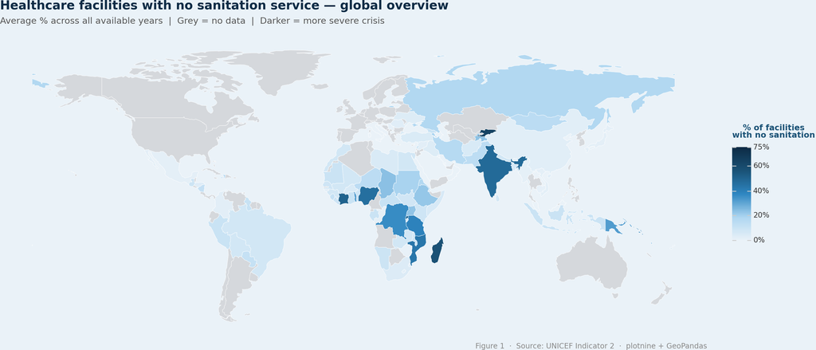

Figure 1: Average % of healthcare facilities with no sanitation service by country. Grey = no data.

```python
SHAPEFILE = "/usr/local/lib/python3.12/dist-packages/pyogrio/tests/fixtures/naturalearth_lowres/naturalearth_lowres.shp"
world_gdf    = gpd.read_file(SHAPEFILE).to_crs("EPSG:4326")
world_merged = world_gdf.merge(country_avg_pd, left_on="iso_a3", right_on="alpha_3_code", how="left")

(
    ggplot(world_merged)
    + geom_map(aes(fill="avg_no_sanitation"), color="white", size=0.2)
    + scale_fill_gradientn(
        colors=["#eaf2f8","#aed6f1","#2e86c1","#1a5276","#0d2b45"],
        na_value="#d5d8dc", name="% of facilities\nwith no sanitation",
        limits=(0,75), breaks=[0,20,40,60,75],
        labels=["0%","20%","40%","60%","75%"]
    )
    + coord_cartesian(xlim=(-180,180), ylim=(-55,85))
    + labs(
        title="Healthcare facilities with no sanitation service — global overview",
        subtitle="Average % across all available years  |  Grey = no data  |  Darker = more severe crisis",
        caption="Figure 1  ·  Source: UNICEF Indicator 2  ·  plotnine + GeoPandas"
    )
    + theme_void()
    + theme(
        plot_title=element_text(size=15,weight="bold",color="#0d2b45",margin={"b":6}),
        plot_subtitle=element_text(size=11,color="#555555",margin={"b":10}),
        plot_caption=element_text(size=9,color="#888888"),
        legend_title=element_text(size=10,weight="bold",color="#1a5276"),
        legend_text=element_text(size=9,color="#333333"),
        legend_position="right",
        plot_background=element_rect(fill="#eaf2f8",color="#eaf2f8"),
        panel_background=element_rect(fill="#eaf2f8",color="#eaf2f8"),
        figure_size=(14,6)
    )
)
```

## The Worst Offenders: Top 15 Countries

VISUALISATION 2 · BAR CHART

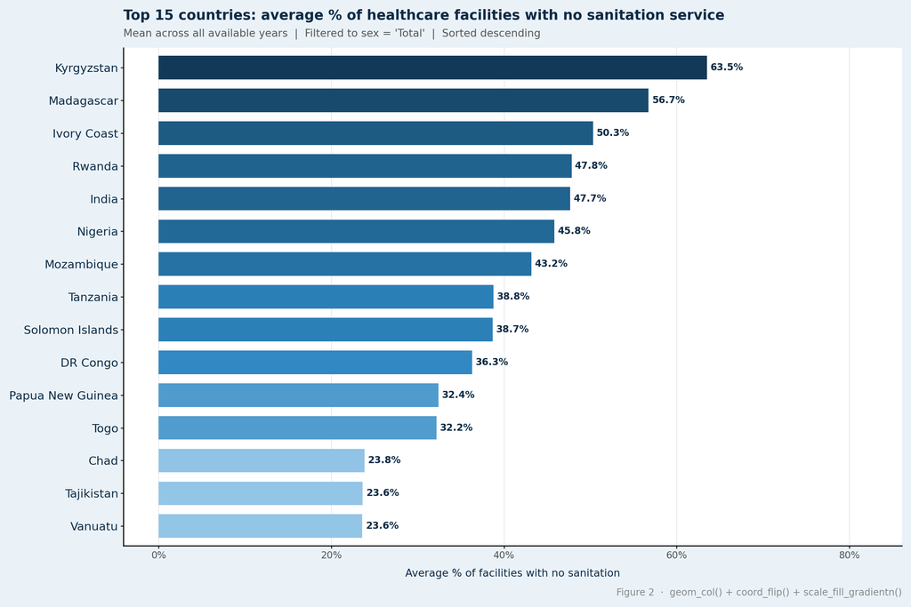

Figure 2: Top 15 countries ranked by average % of healthcare facilities with no sanitation service.

```python
top15_sorted = top15.sort_values("avg_no_sanitation", ascending=True).copy()
top15_sorted["label"] = top15_sorted["avg_no_sanitation"].round(1).astype(str) + "%"
short_names = {"Tanzania, United Republic of":"Tanzania","Congo, the Democratic Republic of the":"DR Congo"}
top15_sorted["country"] = top15_sorted["country"].replace(short_names)
top15_sorted["country"] = pd.Categorical(top15_sorted["country"],categories=top15_sorted["country"].tolist(),ordered=True)

(
    ggplot(top15_sorted, aes(x="country", y="avg_no_sanitation", fill="avg_no_sanitation"))
    + geom_col(width=0.72)
    + geom_text(aes(label="label"), ha="left", nudge_y=0.4, size=9, color="#0d2b45", fontweight="bold")
    + scale_fill_gradientn(colors=["#aed6f1","#2e86c1","#1a5276","#0d2b45"],limits=(20,70),guide=None)
    + scale_y_continuous(limits=(0,82),breaks=[0,20,40,60,80],labels=["0%","20%","40%","60%","80%"])
    + coord_flip()
    + labs(
        title="Top 15 countries: average % of healthcare facilities with no sanitation service",
        subtitle="Mean across all available years  |  Filtered to sex = 'Total'  |  Sorted descending",
        x="", y="Average % of facilities with no sanitation",
        caption="Figure 2  ·  geom_col() + coord_flip() + scale_fill_gradientn()"
    )
    + theme_classic()
    + theme(
        plot_title=element_text(size=13,weight="bold",color="#0d2b45",margin={"b":6}),
        plot_subtitle=element_text(size=10,color="#555555",margin={"b":8}),
        plot_caption=element_text(size=9,color="#888888"),
        axis_text_y=element_text(size=11,color="#0d2b45"),
        axis_text_x=element_text(size=9,color="#555555"),
        axis_title_x=element_text(size=10,color="#0d2b45",margin={"t":8}),
        panel_grid_major_x=element_line(color="#dddddd",size=0.5),
        panel_grid_major_y=element_blank(),
        plot_background=element_rect(fill="#eaf2f8",color="#eaf2f8"),
        panel_background=element_rect(fill="white"),
        figure_size=(12,8)
    )
)
```

**Kyrgyzstan** leads with a staggering **63.5%** — nearly two-thirds of its health facilities offer no sanitation. **India’s** position at 5th is especially alarming: even a modest percentage translates to hundreds of millions of people at risk.

## The Life Expectancy Connection

VISUALISATION 3 · SCATTERPLOT WITH REGRESSION

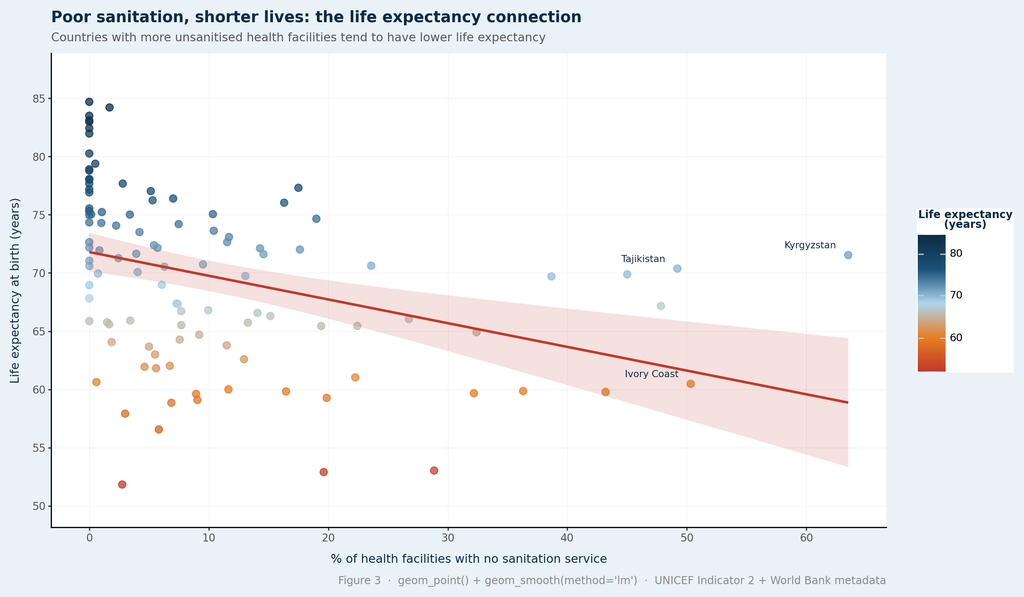

Figure 3: Scatterplot of % no sanitation vs life expectancy at birth. Red line = linear regression.

```python
scatter_agg = (
    scatter_pd.groupby("country")
    .agg(obs_value=("obs_value","mean"),life_exp=("life_exp","mean"))
    .reset_index().dropna(subset=["obs_value","life_exp"]).query("life_exp >= 50")
)
extremes = scatter_agg.nlargest(3,"obs_value")

(
    ggplot(scatter_agg, aes(x="obs_value", y="life_exp"))
    + geom_point(aes(color="life_exp"), size=3, alpha=0.75)
    + geom_smooth(method="lm", color=RED, fill=RED, alpha=0.15, size=1.2)
    + geom_text(data=extremes,mapping=aes(x="obs_value",y="life_exp",label="country"),
                size=8,color="#0d2b45",nudge_y=0.8,nudge_x=-1,ha="right")
    + scale_color_gradientn(colors=["#c0392b","#e67e22","#aed6f1","#1a5276","#0d2b45"],name="Life expectancy\n(years)")
    + scale_x_continuous(name="% of health facilities with no sanitation service",breaks=[0,10,20,30,40,50,60,70])
    + scale_y_continuous(name="Life expectancy at birth (years)",breaks=[50,55,60,65,70,75,80,85],limits=(50,87))
    + labs(
        title="Poor sanitation, shorter lives: the life expectancy connection",
        subtitle="Countries with more unsanitised health facilities tend to have lower life expectancy",
        caption="Figure 3  ·  geom_point() + geom_smooth(method='lm')  ·  UNICEF Indicator 2 + World Bank metadata"
    )
    + theme_classic()
    + theme(
        plot_title=element_text(size=13,weight="bold",color="#0d2b45",margin={"b":6}),
        plot_subtitle=element_text(size=10,color="#555555",margin={"b":8}),
        plot_caption=element_text(size=9,color="#888888"),
        axis_text=element_text(size=9,color="#555555"),
        axis_title=element_text(size=10,color="#0d2b45"),
        legend_title=element_text(size=9,weight="bold",color="#0d2b45"),
        panel_grid_major=element_line(color="#eeeeee",size=0.4),
        plot_background=element_rect(fill="#eaf2f8",color="#eaf2f8"),
        panel_background=element_rect(fill="white"),
        figure_size=(12,7)
    )
)
```

VISUALISATION 4 · TIME-SERIES

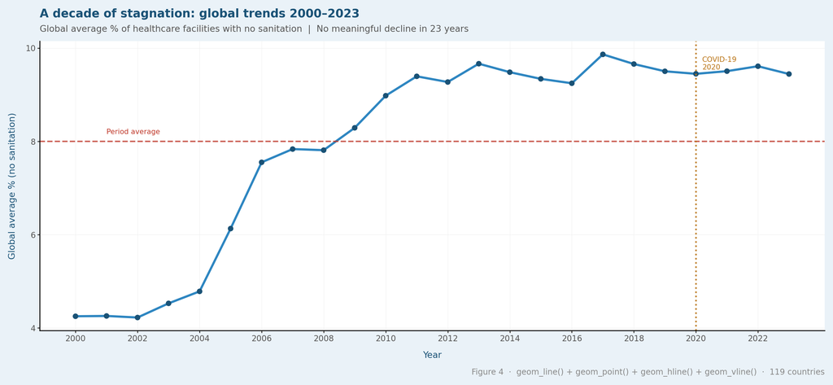

Figure 4: Global average % of healthcare facilities with no sanitation (2000–2023).

```python
(
    ggplot(ts_pd, aes(x="time_period", y="global_mean"))
    + geom_line(color=TEAL, size=1.4)
    + geom_point(color=NAVY, size=2.5)
    + geom_hline(yintercept=ts_pd["global_mean"].mean(),linetype="dashed",color=RED,size=0.9,alpha=0.8)
    + geom_vline(xintercept=2020,linetype="dotted",color=AMBER,size=1,alpha=0.9)
    + annotate("text",x=2020.2,y=ts_pd["global_mean"].max()-0.2,label="COVID-19\n2020",size=8,color=AMBER,ha="left")
    + annotate("text",x=2001,y=ts_pd["global_mean"].mean()+0.2,label="Period average",size=8,color=RED,ha="left")
    + scale_x_continuous(name="Year",breaks=list(range(2000,2024,2)))
    + scale_y_continuous(name="Global average % (no sanitation)",breaks=[4,6,8,10,12])
    + labs(
        title="A decade of stagnation: global trends 2000–2023",
        subtitle="Global average % of healthcare facilities with no sanitation  |  No meaningful decline in 23 years",
        caption="Figure 4  ·  geom_line() + geom_point() + geom_hline() + geom_vline()  ·  119 countries"
    )
    + theme_classic()
    + theme(
        plot_title=element_text(size=13,weight="bold",color=NAVY,margin={"b":6}),
        plot_subtitle=element_text(size=10,color="#555555",margin={"b":8}),
        plot_caption=element_text(size=9,color="#888888"),
        axis_text=element_text(size=9,color="#555555"),
        axis_title=element_text(size=10,color=NAVY),
        panel_grid_major=element_line(color="#eeeeee",size=0.4),
        plot_background=element_rect(fill="#eaf2f8",color="#eaf2f8"),
        panel_background=element_rect(fill="white"),
        figure_size=(13,6)
    )
)
```

## What Needs to Happen

The data makes one thing undeniable: **healthcare sanitation is a global emergency that is not being treated as one.** Three imperatives stand out:

1. **Targeted investment** in the 15 worst-affected countries — especially Kyrgyzstan, Madagascar, India, and Nigeria
2. **Routine data collection** must be strengthened in countries with data gaps
3. **Life expectancy targets cannot be met** without addressing healthcare sanitation

The world cannot call itself committed to universal healthcare while millions of patients enter facilities that lack a working toilet. **The data demands action.**

## About This Report

| Detail | Value |
| --- | --- |
| **Indicator** | Proportion of health care facilities with no sanitation service |
| **Source** | UNICEF Indicator 2 + World Bank Metadata |
| **Countries covered** | 119 |
| **Time period** | 2000–2023 |
| **Tools** | Python · Polars · plotnine · GeoPandas · Quarto |
| **Hosted on** | GitHub Pages |

*Report prepared as part of BAA1030 Data Analytics | DCU Business School*